# DM—關聯式規則(Association rule)

POLab

2017/05/19

[【回到首頁】](https://github.com/PO-LAB/Data-Mining)

本篇內容會介紹關聯式規則(Association rule)的資料探勘模型。

首先，還是要再提醒一下，記得要更新R的版本至[【3.4.0】](http://cran.csie.ntu.edu.tw/)唷！而之後會用到的`arules`套件版本為[【1.5-2】](https://cran.r-project.org/web/packages/arules/index.html)

# **關聯式規則(Apriori)**

這裡拿網路上一個公開資料(鐵達尼號的乘客資料)來進行分析，[資料載點如下](http://www.rdatamining.com/data/titanic.raw.rdata?attredirects=0&d=1)。

下載之後，你會發現資料的型態並非熟悉的.csv。

因此我們要用**函式**把資料匯入到R裡面，使用的函式是`load()`：

```r
# 記得要給定資料所在的路徑(path)，例如：我把下載的資料放在C槽下：
load("C:/titanic.raw.rdata")  #匯入.rdata檔
```

**(補充：如果我們要匯入.csv檔，除了之前教的“Import Dataset”方法以外，也可以用函式`read.csv()`)**

```r
data <- read.csv("C:/Users/Allan/Desktop/R_programmimg/Allan/06/data.csv")
```

並且用`str()`看這筆資料的狀態

```r
str(titanic.raw)
```

```
## 'data.frame':    2201 obs. of  4 variables:
##  $ Class   : Factor w/ 4 levels "1st","2nd","3rd",..: 3 3 3 3 3 3 3 3 3 3 ...
##  $ Sex     : Factor w/ 2 levels "Female","Male": 2 2 2 2 2 2 2 2 2 2 ...
##  $ Age     : Factor w/ 2 levels "Adult","Child": 2 2 2 2 2 2 2 2 2 2 ...
##  $ Survived: Factor w/ 2 levels "No","Yes": 1 1 1 1 1 1 1 1 1 1 ...
```

可以發現資料裡面有四個欄位：

1. Class：乘客的艙位等級
2. Sex：乘客性別
3. Age ：乘客年齡
4. Survived：沉船之後，乘客是否存活？

關於鐵達尼號的故事，大家應該都耳熟能詳。而當我們說「女性比較容易存活」、以及「男性船員幾乎活不下來」，相信也沒人會反對吧？但是凡事講求證據~

事實上證明其實並不難，而其中一個方法，就是本篇即將用到的第一個方法：**關聯式規則(apriori)**！(對應的套件：`arules`)

```r
require(arules) # apriori關聯式規則的套件
```

還記得apriori演算法是怎麼運作的嗎？我們需要設定：

- 最小支持度(min support)：「規則」在資料內具有普遍性
- 最小信賴度(min confidence)：「規則」要有一定的信心水準

而我們想要探討的規則，形式如下：「在A情況下，會存活與否」

換句話說，可以寫成**A => 存活與否**，所以把Survived這個變數放在`=>`的右手邊(right hand side)

```r
# apriori rules with rhs containing "Survived" only

rule <- apriori(titanic.raw,
                # min support & confidence, 最小規則長度(lhs+rhs)
                parameter=list(minlen=3, supp=0.1, conf=0.7),
                appearance = list(default="lhs",
                                  rhs=c("Survived=No", "Survived=Yes")
                                  # 右手邊顯示的特徵
                                  )
                )
```

要觀察rule需要使用`inspect()`的函式：

```r
inspect(rule)
```

```
##     lhs                                rhs            support   confidence
## [1] {Sex=Female,Age=Adult}          => {Survived=Yes} 0.1435711 0.7435294
## [2] {Class=3rd,Sex=Male}            => {Survived=No}  0.1917310 0.8274510
## [3] {Class=3rd,Age=Adult}           => {Survived=No}  0.2162653 0.7591707
## [4] {Class=Crew,Sex=Male}           => {Survived=No}  0.3044071 0.7772622
## [5] {Class=Crew,Age=Adult}          => {Survived=No}  0.3057701 0.7604520
## [6] {Sex=Male,Age=Adult}            => {Survived=No}  0.6038164 0.7972406
## [7] {Class=3rd,Sex=Male,Age=Adult}  => {Survived=No}  0.1758292 0.8376623
## [8] {Class=Crew,Sex=Male,Age=Adult} => {Survived=No}  0.3044071 0.7772622
##     lift
## [1] 2.301699
## [2] 1.222295
## [3] 1.121433
## [4] 1.148157
## [5] 1.123325
## [6] 1.177669
## [7] 1.237379
## [8] 1.148157
```

根據lift，由大到小排序rule：

```r
sort.rule <- sort(rule, by="lift")
inspect(sort.rule)
```

```
##     lhs                                rhs            support   confidence
## [1] {Sex=Female,Age=Adult}          => {Survived=Yes} 0.1435711 0.7435294
## [2] {Class=3rd,Sex=Male,Age=Adult}  => {Survived=No}  0.1758292 0.8376623
## [3] {Class=3rd,Sex=Male}            => {Survived=No}  0.1917310 0.8274510
## [4] {Sex=Male,Age=Adult}            => {Survived=No}  0.6038164 0.7972406
## [5] {Class=Crew,Sex=Male}           => {Survived=No}  0.3044071 0.7772622
## [6] {Class=Crew,Sex=Male,Age=Adult} => {Survived=No}  0.3044071 0.7772622
## [7] {Class=Crew,Age=Adult}          => {Survived=No}  0.3057701 0.7604520
## [8] {Class=3rd,Age=Adult}           => {Survived=No}  0.2162653 0.7591707
##     lift
## [1] 2.301699
## [2] 1.237379
## [3] 1.222295
## [4] 1.177669
## [5] 1.148157
## [6] 1.148157
## [7] 1.123325
## [8] 1.121433
```

看第一個關聯規則：「若身分是成人女性 => 則會存活」，lift=2.3 > 1，表示預測結果比原本表現好。

然而，有發現到問題嗎？

第六個關聯規則(#編號8)「若身分是男性成人船員 => 不會存活」，對比於第五個關聯規則(#編號4)：「若身分是男性船員 => 不會存活」，其實看不到任何有用的資訊！

而且，第六個規則的lift <= 第五個規則的lift， 當發生這樣的情況時，我們就可以說：第六個關聯規則是**多餘的(redundant)**。

多餘的關聯規則，會造成分析上的雜訊，因此需要刪除它們，但該怎麼做呢？

首先，先看某項規則是否為其他規則的子集(subset)：

```r
subset.matrix <- as.matrix(is.subset(x=sort.rule, y=sort.rule))
```

輸出的格式會像這樣：

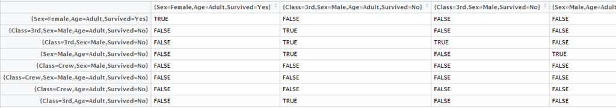

上面的結果要解釋很簡單：在X的項目，如果是Y項目的子集(subset)，就會回傳TRUE。  
(當你用RStudio打開**subset.matrix**這個變數時，會看見一個8x8的矩陣)

之後再進行以下步驟：

```r
# 把這個矩陣的下三角去除，只留上三角的資訊
subset.matrix[lower.tri(subset.matrix, diag=T)] <- NA

# 計算每個column中TRUE的個數，若有一個以上的TRUE，代表此column是多餘的
redundant <- colSums(subset.matrix, na.rm=T) >= 1

# 移除多餘的規則
sort.rule <- sort.rule[!redundant]

inspect(sort.rule)
```

```
##     lhs                               rhs            support   confidence
## [1] {Sex=Female,Age=Adult}         => {Survived=Yes} 0.1435711 0.7435294
## [2] {Class=3rd,Sex=Male,Age=Adult} => {Survived=No}  0.1758292 0.8376623
## [3] {Class=3rd,Sex=Male}           => {Survived=No}  0.1917310 0.8274510
## [4] {Sex=Male,Age=Adult}           => {Survived=No}  0.6038164 0.7972406
## [5] {Class=Crew,Sex=Male}          => {Survived=No}  0.3044071 0.7772622
## [6] {Class=Crew,Age=Adult}         => {Survived=No}  0.3057701 0.7604520
## [7] {Class=3rd,Age=Adult}          => {Survived=No}  0.2162653 0.7591707
##     lift
## [1] 2.301699
## [2] 1.237379
## [3] 1.222295
## [4] 1.177669
## [5] 1.148157
## [6] 1.123325
## [7] 1.121433
```

經過以上步驟後，多餘的規則消失了！

在R裡面，關聯式規則還提供一個視覺化的套件`arulesViz`，可以觀察每條規則的三項指標分布情況：

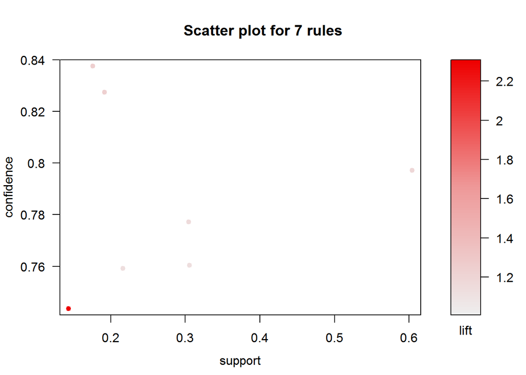

```r
require(arulesViz)
plot(sort.rule)
```

而且也可以將規則視覺化，知道當初災難發生以後，在什麼樣的條件下比較容易存活/死亡：

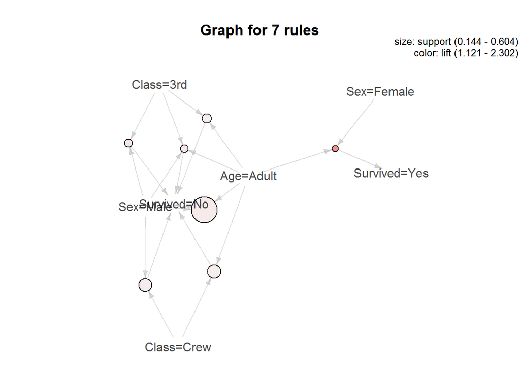

```r
plot(sort.rule, method="graph", control=list(type="items"))
```

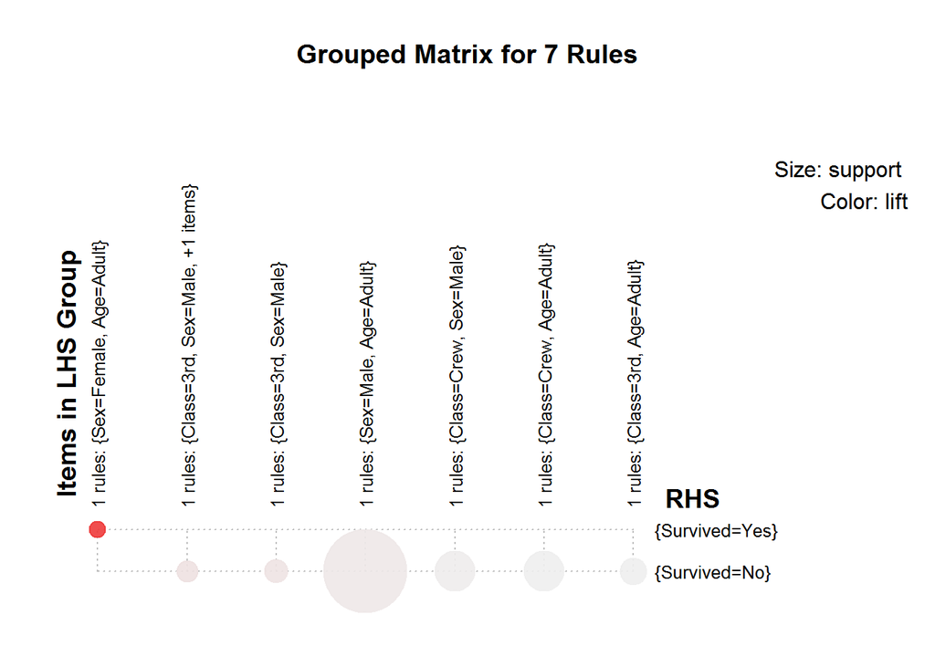

```r
plot(sort.rule, method="grouped")
```

現在對照一開始的假設：**「女性比較容易存活」、「男性船員幾乎死光光」**…(好殘酷)！

而這些規則就是我們的證據了！

# **總結**

和一些機器學習方法只會專注在「預測準確率」的概念不太一樣，，關聯式規則在「解釋」上具有十分強大的優勢。

的確，在現實中，有時候確實只要「高的預測準確率」的模型，就可以達成許多目標。

可是也千萬別忘記了，我們正在進行的是「資料分析」，也就是去「解釋」資料中的故事。

事實上，有時候這個步驟反而會比「準確率」還重要。這一點，稍微思考一下就能理解了：唯有去探討資料的故事，才有機會發現到**有趣的跡象、失敗的原因、違背直覺的現象……**等等。

# **Reference**

[http://www.rdatamining.com/examples/association-rules](http://www.rdatamining.com/examples/association-rules  
)

[https://www.kaggle.com/c/titanic](https://www.kaggle.com/c/titanic  
)